# Anime Rating Case Study

## Context

Streamist is a streaming company that streams web series and movies for a worldwide audience. Every content on their portal is rated by the viewers, and the portal also provides other information for the content like the number of people who have watched it, the number of people who want to watch it, the number of episodes, duration of an episode, etc.

They are currently focusing on the anime available in their portal, and want to identify the most important factors involved in rating an anime. You as a data scientist at Streamist are tasked with identifying the important factors and building a predictive model to predict the rating on an anime.

## Objective

To analyze the data and build a linear regression model to predict the ratings of anime.

## Key Questions

1. What are the key factors influencing the rating of an anime?
2. Is there a good predictive model for the rating of an anime? What does the performance assessment look like for such a model?

## Data Information

Each record in the database provides a description of an anime. A detailed data dictionary can be found below.

**Data Dictionary**

- title - the title of anime
- description - the synopsis of the plot
- mediaType - format of publication
- eps - number of episodes (movies are considered 1 episode)
- duration - duration of an episode in minutes
- ongoing - whether it is ongoing
- sznOfRelease - the season of release (Winter, Spring, Fall)
- years_running - number of years the anime ran/is running
- studio_primary - primary studio of production
- studios_colab - whether there was a collaboration between studios to produce the anime
- contentWarn - whether anime has a content warning
- watched - number of users that completed it
- watching - number of users that are watching it
- wantWatch - number of users that want to watch it
- dropped - number of users that dropped it before completion
- rating - average user rating
- votes - number of votes that contribute to rating
- tag_Based_on_a_Manga - whether the anime is based on a manga
- tag_Comedy - whether the anime is of Comedy genre
- tag_Action - whether the anime is of Action genre
- tag_Fantasy - whether the anime is of Fantasy genre
- tag_Sci_Fi - whether the anime is of Sci-Fi genre
- tag_Shounen - whether the anime has a tag Shounen
- tag_Original_Work - whether the anime is an original work
- tag_Non_Human_Protagonists - whether the anime has any non-human protagonists
- tag_Drama - whether the anime is of Drama genre
- tag_Adventure - whether the anime is of Adventure genre
- tag_Family_Friendly - whether the anime is family-friendly
- tag_Short_Episodes - whether the anime has short episodes
- tag_School_Life - whether the anime is regarding school life
- tag_Romance - whether the anime is of Romance genre
- tag_Shorts - whether the anime has a tag Shorts
- tag_Slice_of_Life - whether the anime has a tag Slice of Life
- tag_Seinen - whether the anime has a tag Seinen
- tag_Supernatural - whether the anime has a tag Supernatural
- tag_Magic - whether the anime has a tag Magic
- tag_Animal_Protagonists - whether the anime has animal protagonists
- tag_Ecchi - whether the anime has a tag Ecchi
- tag_Mecha - whether the anime has a tag Mecha
- tag_Based_on_a_Light_Novel - whether the anime is based on a light novel
- tag_CG_Animation - whether the anime has a tag CG Animation
- tag_Superpowers - whether the anime has a tag Superpowers
- tag_Others - whether the anime has other tags
- tag_is_missing - whether tag is missing or not

## Let's start coding!

### Import necessary libraries

```python
pip install nb_black
```

```python
# this will help in making the Python code more structured automatically (good coding practice)
%load_ext nb_black

# Libraries to help with reading and manipulating data
import numpy as np
import pandas as pd

# Libraries to help with data visualization
import matplotlib.pyplot as plt
import seaborn as sns

# sns.set()

# Removes the limit for the number of displayed columns
pd.set_option("display.max_columns", None)
# Sets the limit for the number of displayed rows
pd.set_option("display.max_rows", 200)

# to split the data into train and test
from sklearn.model_selection import train_test_split

# to build linear regression_model
from sklearn.linear_model import LinearRegression

# to check model performance
from sklearn.metrics import mean_absolute_error, mean_squared_error, r2_score
```

```python
# loading the dataset
df = pd.read_csv("anime_data.csv")
```

```python
# checking shape of the data
print(f"There are {df.shape[0]} rows and {df.shape[1]} columns.")
```

```
There are 12101 rows and 44 columns.
```

```python
# to view first 5 rows of the dataset
df.head()
```

|  | title | description | mediaType | eps | duration | ongoing | sznOfRelease | years_running | studio_primary | studios_colab | contentWarn | watched | watching | wantWatch | dropped | rating | votes | tag_Based_on_a_Manga | tag_Comedy | tag_Action | tag_Fantasy | tag_Sci_Fi | tag_Shounen | tag_Original_Work | tag_Non_Human_Protagonists | tag_Drama | tag_Adventure | tag_Family_Friendly | tag_Short_Episodes | … |
| --- | --- | --- | --- | --- | --- | --- | --- | --- | --- | --- | --- | --- | --- | --- | --- | --- | --- | --- | --- | --- | --- | --- | --- | --- | --- | --- | --- | --- | --- | --- |
| 0 | Fullmetal Alchemist: Brotherhood | The foundation of alchemy is based on the law ... | TV | 64 | NaN | False | Spring | 1 | Bones | 0 | 1 | 103707.0 | 14351 | 25810 | 2656 | 4.702 | 86547 | 1 | 0 | 1 | 1 | 0 | 1 | 0 | 0 | 1 | 1 | 0 | 0 | … |
| 1 | your name. | Mitsuha and Taki are two total strangers livin... | Movie | 1 | 107.0 | False | is_missing | 0 | Others | 0 | 0 | 58831.0 | 1453 | 21733 | 124 | 4.663 | 43960 | 0 | 0 | 0 | 0 | 0 | 0 | 1 | 0 | 1 | 0 | 0 | 0 | … |
| 2 | A Silent Voice | After transferring into a new school, a deaf g... | Movie | 1 | 130.0 | False | is_missing | 0 | Kyoto Animation | 0 | 1 | 45892.0 | 946 | 17148 | 132 | 4.661 | 33752 | 1 | 0 | 0 | 0 | 0 | 1 | 0 | 0 | 1 | 0 | 0 | 0 | … |
| 3 | Haikyuu!! Karasuno High School vs Shiratorizaw... | Picking up where the second season ended, the ... | TV | 10 | NaN | False | Fall | 0 | Production I.G | 0 | 0 | 25134.0 | 2183 | 8082 | 167 | 4.660 | 17422 | 1 | 0 | 0 | 0 | 0 | 1 | 0 | 0 | 0 | 0 | 0 | 0 | … |
| 4 | Attack on Titan 3rd Season: Part II | The battle to retake Wall Maria begins now! Wi... | TV | 10 | NaN | False | Spring | 0 | Others | 0 | 1 | 21308.0 | 3217 | 7864 | 174 | 4.650 | 15789 | 1 | 0 | 1 | 1 | 0 | 1 | 0 | 0 | 0 | 0 | 0 | 0 | … |

```python
# to view last 5 rows of the dataset
df.tail()
```

|  | title | description | mediaType | eps | duration | ongoing | sznOfRelease | years_running | studio_primary | studios_colab | contentWarn | watched | watching | wantWatch | dropped | rating | votes | tag_Based_on_a_Manga | tag_Comedy | tag_Action | tag_Fantasy | tag_Sci_Fi | tag_Shounen | tag_Original_Work | tag_Non_Human_Protagonists | tag_Drama | tag_Adventure | tag_Family_Friendly | tag_Short_Episodes | … |
| --- | --- | --- | --- | --- | --- | --- | --- | --- | --- | --- | --- | --- | --- | --- | --- | --- | --- | --- | --- | --- | --- | --- | --- | --- | --- | --- | --- | --- | --- | --- |
| 12096 | Sore Ike! Anpanman: Kirameke! Ice no Kuni no V... | Princess Vanilla is a princess in a land of ic... | Movie | 1 | NaN | False | is_missing | 0 | TMS Entertainment | 0 | 0 | 22.0 | 1 | 29 | 1 | 2.807 | 10 | 0 | 0 | 0 | 0 | 0 | 0 | 0 | 1 | 0 | 0 | 1 | 0 | … |
| 12097 | Hulaing Babies Petit | NaN | TV | 12 | 5.0 | False | Winter | 0 | Others | 0 | 0 | 13.0 | 10 | 77 | 2 | 2.090 | 10 | 0 | 1 | 0 | 0 | 0 | 0 | 1 | 0 | 0 | 0 | 0 | 1 | … |
| 12098 | Marco & The Galaxy Dragon | NaN | OVA | 1 | NaN | False | is_missing | 0 | is_missing | 0 | 0 | 17.0 | 0 | 65 | 0 | 2.543 | 10 | 0 | 1 | 1 | 0 | 0 | 0 | 0 | 0 | 0 | 0 | 0 | 0 | … |
| 12099 | Xing Chen Bian 2nd Season | Second season of Xing Chen Bian. | Web | 3 | 24.0 | True | is_missing | 0 | is_missing | 0 | 0 | 40.5 | 31 | 22 | 0 | 3.941 | 10 | 0 | 0 | 1 | 0 | 0 | 0 | 0 | 0 | 0 | 0 | 0 | 0 | … |
| 12100 | Ultra B: Black Hole kara no Dokusaisha BB!! | NaN | Movie | 1 | 20.0 | False | is_missing | 0 | Shin-Ei Animation | 0 | 0 | 15.0 | 1 | 19 | 1 | 2.925 | 10 | 1 | 1 | 0 | 0 | 1 | 0 | 0 | 0 | 0 | 0 | 0 | 0 | … |

```python
# let's create a copy of the data to avoid any changes to original data
data = df.copy()
```

```python
# checking for duplicate values in the data
data.duplicated().sum()
```

```
0
```

- There are no duplicate values in the data.

```python
# checking the names of the columns in the data
print(data.columns)
```

```
Index(['title', 'description', 'mediaType', 'eps', 'duration', 'ongoing',
       'sznOfRelease', 'years_running', 'studio_primary', 'studios_colab',
       'contentWarn', 'watched', 'watching', 'wantWatch', 'dropped', 'rating',
       'votes', 'tag_Based_on_a_Manga', 'tag_Comedy', 'tag_Action',
       'tag_Fantasy', 'tag_Sci_Fi', 'tag_Shounen', 'tag_Original_Work',
       'tag_Non_Human_Protagonists', 'tag_Drama', 'tag_Adventure',
       'tag_Family_Friendly', 'tag_Short_Episodes', 'tag_School_Life',
       'tag_Romance', 'tag_Shorts', 'tag_Slice_of_Life', 'tag_Seinen',
       'tag_Supernatural', 'tag_Magic', 'tag_Animal_Protagonists', 'tag_Ecchi',
       'tag_Mecha', 'tag_Based_on_a_Light_Novel', 'tag_CG_Animation',
       'tag_Superpowers', 'tag_Others', 'tag_missing'],
      dtype='object')
```

```python
# checking column datatypes and number of non-null values
data.info()
```

```
<class 'pandas.core.frame.DataFrame'>
RangeIndex: 12101 entries, 0 to 12100
Data columns (total 44 columns):
 #   Column                      Non-Null Count  Dtype
---  ------                      --------------  -----
 0   title                       12101 non-null  object
 1   description                 7633 non-null   object
 2   mediaType                   12101 non-null  object
 3   eps                         12101 non-null  int64
 4   duration                    7465 non-null   float64
 5   ongoing                     12101 non-null  bool
 6   sznOfRelease                12101 non-null  object
 7   years_running               12101 non-null  int64
 8   studio_primary              12101 non-null  object
 9   studios_colab               12101 non-null  int64
```

[output cut: 36 more lines]

- Dependent variable is the rating of an anime, which if of *float* type.
- *title*, *description*, *mediaType*, *sznOfRelease*, *studio_primary* are of *object* type.
- *ongoing* column is of *bool* type.
- All other columns are numeric in nature.
- There are missing values in the *description* and *duration* columns.

**Let's check for missing values in the data.**

```python
# checking for missing values in the data
data.isnull().sum()
```

```
title                            0
description                   4468
mediaType                        0
eps                              0
duration                      4636
ongoing                          0
sznOfRelease                     0
years_running                    0
studio_primary                   0
studios_colab                    0
contentWarn                      0
watched                          0
watching                         0
wantWatch                        0
dropped                          0
rating                           0
votes                            0
tag_Based_on_a_Manga             0
tag_Comedy                       0
tag_Action                       0
tag_Fantasy                      0
tag_Sci_Fi                       0
tag_Shounen                      0
tag_Original_Work                0
tag_Non_Human_Protagonists       0
tag_Drama                        0
tag_Adventure                    0
tag_Family_Friendly              0
tag_Short_Episodes               0
tag_School_Life                  0
tag_Romance                      0
tag_Shorts                       0
tag_Slice_of_Life                0
tag_Seinen                       0
tag_Supernatural                 0
tag_Magic                        0
tag_Animal_Protagonists          0
tag_Ecchi                        0
tag_Mecha                        0
tag_Based_on_a_Light_Novel       0
tag_CG_Animation                 0
tag_Superpowers                  0
tag_Others                       0
tag_missing                      0
dtype: int64
```

- *duration* column has 4636 missing values, and *description* column has 4468 missing values.
- No other column has missing values.

```python
# Let's look at the statistical summary of the data
data.describe().T
```

|  | count | mean | std | min | 25% | 50% | 75% | max |
| --- | --- | --- | --- | --- | --- | --- | --- | --- |
| eps | 12101.0 | 13.393356 | 57.925097 | 1.000 | 1.000 | 2.000 | 12.000 | 2527.000 |
| duration | 7465.0 | 24.230141 | 31.468171 | 1.000 | 4.000 | 8.000 | 30.000 | 163.000 |
| years_running | 12101.0 | 0.283200 | 1.152234 | 0.000 | 0.000 | 0.000 | 0.000 | 51.000 |
| studios_colab | 12101.0 | 0.051649 | 0.221326 | 0.000 | 0.000 | 0.000 | 0.000 | 1.000 |
| contentWarn | 12101.0 | 0.115362 | 0.319472 | 0.000 | 0.000 | 0.000 | 0.000 | 1.000 |
| watched | 12101.0 | 2862.605694 | 7724.347024 | 0.000 | 55.000 | 341.000 | 2026.000 | 161567.000 |
| watching | 12101.0 | 256.334435 | 1380.840902 | 0.000 | 2.000 | 14.000 | 100.000 | 74537.000 |
| wantWatch | 12101.0 | 1203.681431 | 2294.327380 | 0.000 | 49.000 | 296.000 | 1275.000 | 28541.000 |
| dropped | 12101.0 | 151.568383 | 493.931710 | 0.000 | 3.000 | 12.000 | 65.000 | 19481.000 |
| rating | 12101.0 | 2.949037 | 0.827385 | 0.844 | 2.304 | 2.965 | 3.616 | 4.702 |
| votes | 12101.0 | 2088.124700 | 5950.332228 | 10.000 | 34.000 | 219.000 | 1414.000 | 131067.000 |
| tag_Based_on_a_Manga | 12101.0 | 0.290802 | 0.454151 | 0.000 | 0.000 | 0.000 | 1.000 | 1.000 |
| tag_Comedy | 12101.0 | 0.272870 | 0.445453 | 0.000 | 0.000 | 0.000 | 1.000 | 1.000 |
| tag_Action | 12101.0 | 0.231221 | 0.421631 | 0.000 | 0.000 | 0.000 | 0.000 | 1.000 |
| tag_Fantasy | 12101.0 | 0.181555 | 0.385493 | 0.000 | 0.000 | 0.000 | 0.000 | 1.000 |
| tag_Sci_Fi | 12101.0 | 0.166267 | 0.372336 | 0.000 | 0.000 | 0.000 | 0.000 | 1.000 |
| tag_Shounen | 12101.0 | 0.144864 | 0.351978 | 0.000 | 0.000 | 0.000 | 0.000 | 1.000 |
| tag_Original_Work | 12101.0 | 0.135195 | 0.341946 | 0.000 | 0.000 | 0.000 | 0.000 | 1.000 |
| tag_Non_Human_Protagonists | 12101.0 | 0.112470 | 0.315957 | 0.000 | 0.000 | 0.000 | 0.000 | 1.000 |
| tag_Drama | 12101.0 | 0.106107 | 0.307987 | 0.000 | 0.000 | 0.000 | 0.000 | 1.000 |
| tag_Adventure | 12101.0 | 0.103793 | 0.305005 | 0.000 | 0.000 | 0.000 | 0.000 | 1.000 |
| tag_Family_Friendly | 12101.0 | 0.097017 | 0.295993 | 0.000 | 0.000 | 0.000 | 0.000 | 1.000 |
| tag_Short_Episodes | 12101.0 | 0.096934 | 0.295880 | 0.000 | 0.000 | 0.000 | 0.000 | 1.000 |
| tag_School_Life | 12101.0 | 0.092306 | 0.289470 | 0.000 | 0.000 | 0.000 | 0.000 | 1.000 |
| tag_Romance | 12101.0 | 0.092141 | 0.289237 | 0.000 | 0.000 | 0.000 | 0.000 | 1.000 |
| tag_Shorts | 12101.0 | 0.089662 | 0.285709 | 0.000 | 0.000 | 0.000 | 0.000 | 1.000 |
| tag_Slice_of_Life | 12101.0 | 0.080820 | 0.272569 | 0.000 | 0.000 | 0.000 | 0.000 | 1.000 |
| tag_Seinen | 12101.0 | 0.077101 | 0.266763 | 0.000 | 0.000 | 0.000 | 0.000 | 1.000 |
| tag_Supernatural | 12101.0 | 0.070903 | 0.256674 | 0.000 | 0.000 | 0.000 | 0.000 | 1.000 |
| tag_Magic | 12101.0 | 0.064292 | 0.245283 | 0.000 | 0.000 | 0.000 | 0.000 | 1.000 |
| tag_Animal_Protagonists | 12101.0 | 0.060326 | 0.238099 | 0.000 | 0.000 | 0.000 | 0.000 | 1.000 |
| tag_Ecchi | 12101.0 | 0.057433 | 0.232678 | 0.000 | 0.000 | 0.000 | 0.000 | 1.000 |
| tag_Mecha | 12101.0 | 0.054541 | 0.227091 | 0.000 | 0.000 | 0.000 | 0.000 | 1.000 |
| tag_Based_on_a_Light_Novel | 12101.0 | 0.053384 | 0.224807 | 0.000 | 0.000 | 0.000 | 0.000 | 1.000 |
| tag_CG_Animation | 12101.0 | 0.050079 | 0.218116 | 0.000 | 0.000 | 0.000 | 0.000 | 1.000 |
| tag_Superpowers | 12101.0 | 0.044624 | 0.206486 | 0.000 | 0.000 | 0.000 | 0.000 | 1.000 |
| tag_Others | 12101.0 | 0.090654 | 0.287128 | 0.000 | 0.000 | 0.000 | 0.000 | 1.000 |
| tag_missing | 12101.0 | 0.025866 | 0.158741 | 0.000 | 0.000 | 0.000 | 0.000 | 1.000 |

- We can see that the anime ratings vary between 0.844 and 4.702, which suggests that the anime were rated on a scale of 0-5.
- 50% of the anime in the data have a runtime less than or equal to 8 minutes.
- Some anime even have a runtime of 1 minute.
  - This seems strange at first, but a Google search can reveal that there are indeed such anime.
- At least 75% of the anime have run for less than a year.
  - This may be because the listed anime has few episodes only.
- At least 75% of the anime have no content warnings.
- The number of views for the anime in the data has a very wide range (0 to more than 160,000).

**Let's look at the non-numeric columns.**

```python
# filtering non-numeric columns
cat_columns = data.select_dtypes(exclude=np.number).columns
cat_columns
```

```
Index(['title', 'description', 'mediaType', 'ongoing', 'sznOfRelease',
       'studio_primary'],
      dtype='object')
```

```python
data["description"].nunique()
```

```
7572
```

```python
# we will skip the title and description columns as they will have a lot of unique values
cat_col = ["mediaType", "ongoing", "sznOfRelease", "studio_primary"]

# printing the number of occurrences of each unique value in each categorical column
for column in cat_col:
    print(data[column].value_counts())
    print("-" * 50)
```

```
TV             3993
Movie          1928
OVA            1770
Music Video    1290
Web            1170
DVD Special     803
Other           580
TV Special      504
is_missing       63
Name: mediaType, dtype: int64
--------------------------------------------------
False    11986
True       115
Name: ongoing, dtype: int64
--------------------------------------------------
is_missing    8554
Spring        1135
Fall          1011
Winter         717
Summer         684
Name: sznOfRelease, dtype: int64
--------------------------------------------------
Others                  4340
is_missing              3208
Toei Animation           636
Sunrise                  430
J.C. Staff               341
MADHOUSE                 337
TMS Entertainment        317
Production I.G           271
Studio Deen              260
Studio Pierrot           221
OLM                      210
A-1 Pictures             194
AIC                      167
Shin-Ei Animation        164
Nippon Animation         145
Tatsunoko Production     144
DLE                      130
GONZO                    124
Bones                    121
Shaft                    118
XEBEC                    117
Kyoto Animation          106
Name: studio_primary, dtype: int64
--------------------------------------------------
```

**We will drop the *title* and *description* columns before moving forward as they have a lot of text in them.**

```python
data.drop(["title", "description"], axis=1, inplace=True)
```

### We will fill the remaining missing values in *duration* column by column median.

```python
data["duration"].fillna(data.duration.median(), inplace=True)
data.isnull().sum()
```

```
mediaType                     0
eps                           0
duration                      0
ongoing                       0
sznOfRelease                  0
years_running                 0
studio_primary                0
studios_colab                 0
contentWarn                   0
watched                       0
watching                      0
wantWatch                     0
dropped                       0
rating                        0
votes                         0
tag_Based_on_a_Manga          0
tag_Comedy                    0
tag_Action                    0
tag_Fantasy                   0
tag_Sci_Fi                    0
tag_Shounen                   0
tag_Original_Work             0
tag_Non_Human_Protagonists    0
tag_Drama                     0
tag_Adventure                 0
tag_Family_Friendly           0
tag_Short_Episodes            0
tag_School_Life               0
tag_Romance                   0
tag_Shorts                    0
tag_Slice_of_Life             0
tag_Seinen                    0
tag_Supernatural              0
tag_Magic                     0
tag_Animal_Protagonists       0
tag_Ecchi                     0
tag_Mecha                     0
tag_Based_on_a_Light_Novel    0
tag_CG_Animation              0
tag_Superpowers               0
tag_Others                    0
tag_missing                   0
dtype: int64
```

## Let's visualize the data

### Univariate Analysis

```python
# function to plot a boxplot and a histogram along the same scale.


def histogram_boxplot(data, feature, figsize=(12, 7), kde=False, bins=None):
    """
    Boxplot and histogram combined

    data: dataframe
    feature: dataframe column
    figsize: size of figure (default (12,7))
    kde: whether to the show density curve (default False)
    bins: number of bins for histogram (default None)
    """
    f2, (ax_box2, ax_hist2) = plt.subplots(
        nrows=2,  # Number of rows of the subplot grid= 2
        sharex=True,  # x-axis will be shared among all subplots
        gridspec_kw={"height_ratios": (0.25, 0.75)},
        figsize=figsize,
    )  # creating the 2 subplots

    sns.boxplot(
        data=data, x=feature, ax=ax_box2, showmeans=True, color="violet"
    )  # boxplot will be created and a star will indicate the mean value of the column

    sns.histplot(
        data=data, x=feature, kde=kde, ax=ax_hist2, bins=bins, palette="winter"
    ) if bins else sns.histplot(
        data=data, x=feature, kde=kde, ax=ax_hist2
    )  # For histogram

    ax_hist2.axvline(
        data[feature].mean(), color="green", linestyle="--"
    )  # Add mean to the histogram
    ax_hist2.axvline(
        data[feature].median(), color="black", linestyle="-"
    )  # Add median to the histogram
```

### *rating* (the target variable)

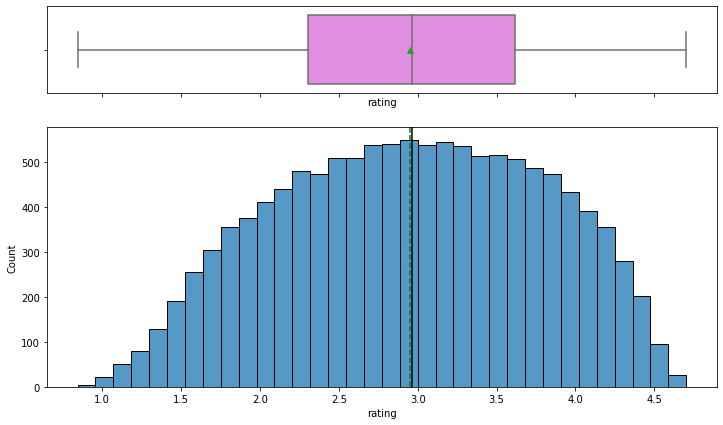

```python
histogram_boxplot(data, "rating")
```

- The anime ratings are close to normally distributed.

### *eps*

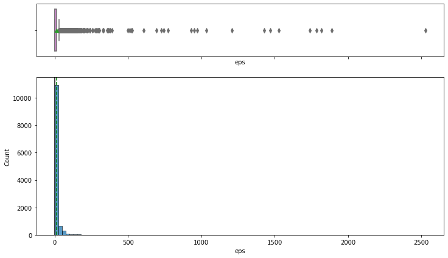

```python
histogram_boxplot(data, "eps", bins=100)
```

```python
data["eps"].describe()
```

```
count    12101.000000
mean        13.393356
std         57.925097
min          1.000000
25%          1.000000
50%          2.000000
75%         12.000000
max       2527.000000
Name: eps, dtype: float64
```

- The distribution is heavily right-skewed, as there are many anime movies in the data, and they are considered to be of only one episode (as per data description).

### *duration*

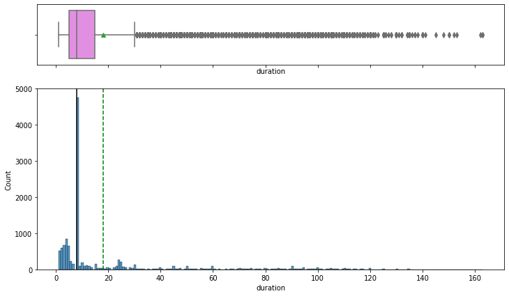

```python
histogram_boxplot(data, "duration")
```

```python
data["duration"].describe()
```

[output not shown]

- The distribution is right-skewed with a median runtime of less than 10 minutes.

### *watched*

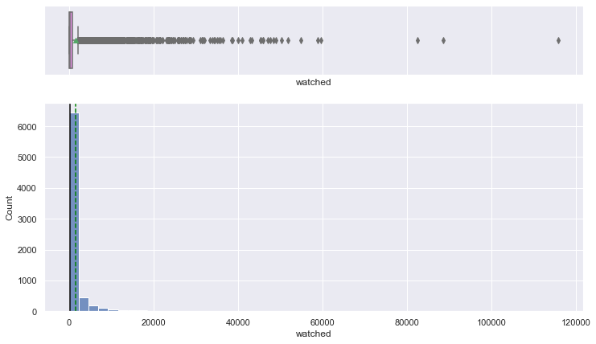

```python
histogram_boxplot(data, "watched", bins=50)
```

```python
data["watched"].describe()
```

[output not shown]

- The distribution is heavily right-skewed, and most of the anime having less than 500 viewers.

### *years_running*

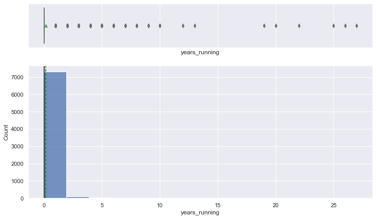

```python
histogram_boxplot(data, "years_running")
```

```python
data["years_running"].describe()
```

[output not shown]

- The distribution is heavily right-skewed, and most of the anime have run for less than 1 year.

### *mediaType*

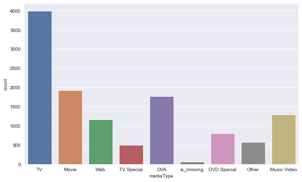

```python
sns.set({"figure.figsize": (10, 6)})
sns.countplot(data=data, x="mediaType")
```

```python
data["mediaType"].value_counts()
```

```
TV             3993
Movie          1928
OVA            1770
Music Video    1290
Web            1170
DVD Special     803
Other           580
TV Special      504
is_missing       63
Name: mediaType, dtype: int64
```

### *ongoing*

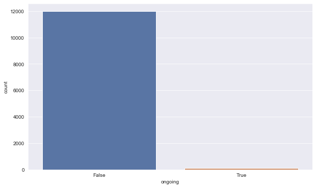

```python
sns.set({"figure.figsize": (10, 6)})
sns.countplot(data=data, x="ongoing")
```

```python
data["ongoing"].value_counts()
```

```
False    11986
True       115
Name: ongoing, dtype: int64
```

- Very few anime in the data are ongoing.

### *sznOfRelease*

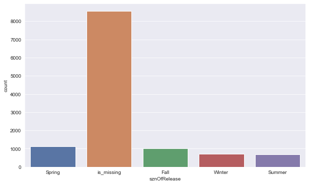

```python
sns.set({"figure.figsize": (10, 6)})
sns.countplot(data=data, x="sznOfRelease")
```

```python
data["sznOfRelease"].value_counts()
```

```
is_missing    8554
Spring        1135
Fall          1011
Winter         717
Summer         684
Name: sznOfRelease, dtype: int64
```

- The season of release of anime is spread out across all seasons when the value is available.

### *studio_primary*

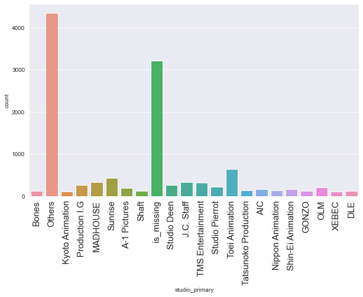

```python
plt.xticks(rotation=90, fontsize=15)
sns.set({"figure.figsize": (14, 6)})
sns.countplot(data=data, x="studio_primary")
```

```python
data["studio_primary"].value_counts()
```

```
Others                  4340
is_missing              3208
Toei Animation           636
Sunrise                  430
J.C. Staff               341
MADHOUSE                 337
TMS Entertainment        317
Production I.G           271
Studio Deen              260
Studio Pierrot           221
OLM                      210
A-1 Pictures             194
AIC                      167
Shin-Ei Animation        164
Nippon Animation         145
Tatsunoko Production     144
DLE                      130
GONZO                    124
Bones                    121
Shaft                    118
XEBEC                    117
Kyoto Animation          106
Name: studio_primary, dtype: int64
```

- *Toei Animation* is the most common studio among the available studio names.

```python
# creating a list of tag columns
tag_cols = [item for item in data.columns if "tag" in item]

# printing the number of occurrences of each unique value in each categorical column
for column in tag_cols:
    print(data[column].value_counts())
    print("-" * 50)
```

```
0    8582
1    3519
Name: tag_Based_on_a_Manga, dtype: int64
--------------------------------------------------
0    8799
1    3302
Name: tag_Comedy, dtype: int64
--------------------------------------------------
0    9303
1    2798
Name: tag_Action, dtype: int64
--------------------------------------------------
0    9904
1    2197
Name: tag_Fantasy, dtype: int64
--------------------------------------------------
0    10089
1     2012
Name: tag_Sci_Fi, dtype: int64
--------------------------------------------------
0    10348
1     1753
Name: tag_Shounen, dtype: int64
--------------------------------------------------
0    10465
1     1636
Name: tag_Original_Work, dtype: int64
--------------------------------------------------
0    10740
1     1361
Name: tag_Non_Human_Protagonists, dtype: int64
--------------------------------------------------
0    10817
1     1284
Name: tag_Drama, dtype: int64
--------------------------------------------------
0    10845
1     1256
Name: tag_Adventure, dtype: int64
--------------------------------------------------
```

[output cut: 53 more lines]

```
1      606
Name: tag_CG_Animation, dtype: int64
--------------------------------------------------
0    11561
1      540
Name: tag_Superpowers, dtype: int64
--------------------------------------------------
0    11004
1     1097
Name: tag_Others, dtype: int64
--------------------------------------------------
0    11788
1      313
Name: tag_missing, dtype: int64
--------------------------------------------------
```

- There are 3519 anime that are based on manga.
- There are 3302 anime of the Comedy genre.

### Bivariate analysis

**We will not consider the *tag* columns for correlation check as they have only 0 or 1 values.**

```python
# creating a list of non-tag columns
corr_cols = [item for item in data.columns if "tag" not in item]
print(corr_cols)
```

```
['mediaType', 'eps', 'duration', 'ongoing', 'sznOfRelease', 'years_running', 'studio_primary', 'studios_colab', 'contentWarn', 'watched', 'watching', 'wantWatch', 'dropped', 'rating', 'votes']
```

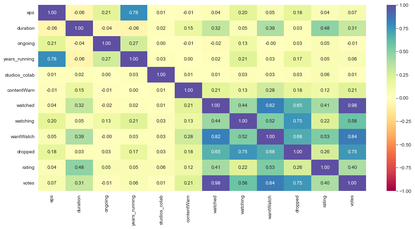

```python
plt.figure(figsize=(15, 7))
sns.heatmap(
    df[corr_cols].corr(), annot=True, vmin=-1, vmax=1, fmt=".2f", cmap="Spectral"
)
plt.show()
```

- *watched* and *wantWatch* columns are highly correlated.
- *watched* and *votes* columns are very highly correlated.
- *wantWatch* and *votes* columns are highly correlated.
- *years_running* and *eps* columns are highly correlated

### Let's check the variation in *rating* with some of the categorical columns in our data

### *mediaType* vs *rating*

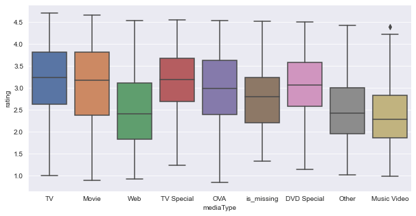

```python
plt.figure(figsize=(10, 5))
sns.boxplot(x="mediaType", y="rating", data=data)
plt.show()
```

### *sznOfRelease* vs *rating*

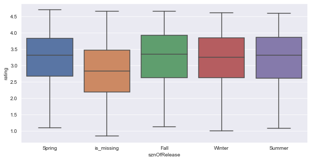

```python
plt.figure(figsize=(10, 5))
sns.boxplot(x="sznOfRelease", y="rating", data=data)
plt.show()
```

- Anime ratings are almost uniformly spread across all the seasons of release.

### *studio_primary* vs *rating*

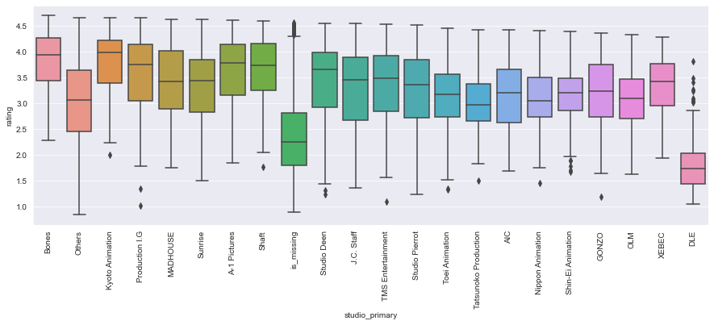

```python
plt.figure(figsize=(15, 5))
sns.boxplot(x="studio_primary", y="rating", data=data)
plt.xticks(rotation=90)
plt.show()
```

- In general, the ratings are low for anime produced by *DLE* studios.
- Ratings are also low, in general, for anime produced by studios other than the ones in the data.

**We will drop the *votes* column from the data as *watched* and *votes* columns are very highly correlated.**

```python
data.drop("votes", axis=1, inplace=True)
data.shape
```

```
(12101, 41)
```

## Model Building

### Define independent and dependent variables

```python
X = data.drop(["rating"], axis=1)
y = data["rating"]
```

### Creating dummy variables

```python
X = pd.get_dummies(
    X,
    columns=X.select_dtypes(include=["object", "category"]).columns.tolist(),
    drop_first=True,
)
X.head()
```

|  | eps | duration | ongoing | years_running | studios_colab | contentWarn | watched | watching | wantWatch | dropped | tag_Based_on_a_Manga | tag_Comedy | tag_Action | tag_Fantasy | tag_Sci_Fi | tag_Shounen | tag_Original_Work | tag_Non_Human_Protagonists | tag_Drama | tag_Adventure | tag_Family_Friendly | tag_Short_Episodes | tag_School_Life | tag_Romance | tag_Shorts | tag_Slice_of_Life | tag_Seinen | tag_Supernatural | tag_Magic | … |
| --- | --- | --- | --- | --- | --- | --- | --- | --- | --- | --- | --- | --- | --- | --- | --- | --- | --- | --- | --- | --- | --- | --- | --- | --- | --- | --- | --- | --- | --- | --- |
| 0 | 64 | 8.0 | False | 1 | 0 | 1 | 103707.0 | 14351 | 25810 | 2656 | 1 | 0 | 1 | 1 | 0 | 1 | 0 | 0 | 1 | 1 | 0 | 0 | 0 | 0 | 0 | 0 | 0 | 0 | 0 | … |
| 1 | 1 | 107.0 | False | 0 | 0 | 0 | 58831.0 | 1453 | 21733 | 124 | 0 | 0 | 0 | 0 | 0 | 0 | 1 | 0 | 1 | 0 | 0 | 0 | 1 | 1 | 0 | 0 | 0 | 1 | 0 | … |
| 2 | 1 | 130.0 | False | 0 | 0 | 1 | 45892.0 | 946 | 17148 | 132 | 1 | 0 | 0 | 0 | 0 | 1 | 0 | 0 | 1 | 0 | 0 | 0 | 1 | 0 | 0 | 0 | 0 | 0 | 0 | … |
| 3 | 10 | 8.0 | False | 0 | 0 | 0 | 25134.0 | 2183 | 8082 | 167 | 1 | 0 | 0 | 0 | 0 | 1 | 0 | 0 | 0 | 0 | 0 | 0 | 1 | 0 | 0 | 0 | 0 | 0 | 0 | … |
| 4 | 10 | 8.0 | False | 0 | 0 | 1 | 21308.0 | 3217 | 7864 | 174 | 1 | 0 | 1 | 1 | 0 | 1 | 0 | 0 | 0 | 0 | 0 | 0 | 0 | 0 | 0 | 0 | 0 | 0 | 0 | … |

```python
X.shape
```

```
(12101, 70)
```

### Split the data into train and test

```python
# splitting the data in 70:30 ratio for train to test data

x_train, x_test, y_train, y_test = train_test_split(X, y, test_size=0.3, random_state=1)
```

```python
print("Number of rows in train data =", x_train.shape[0])
print("Number of rows in test data =", x_test.shape[0])
```

```
Number of rows in train data = 8470
Number of rows in test data = 3631
```

### Fitting a linear model

```python
lin_reg_model = LinearRegression()
lin_reg_model.fit(x_train, y_train)
```

```
LinearRegression()
```

**Let us check the coefficients and intercept of the model, which are the parameters we learned.**

```python
coef_df = pd.DataFrame(
    np.append(lin_reg_model.coef_, lin_reg_model.intercept_),
    index=x_train.columns.tolist() + ["Intercept"],
    columns=["Coefficients"],
)
coef_df
```

|  | Coefficients |
| --- | --- |
| eps | -0.000205 |
| duration | 0.003094 |
| ongoing | 0.380299 |
| years_running | 0.034990 |
| studios_colab | -0.015972 |
| contentWarn | -0.162190 |
| watched | -0.000002 |
| watching | 0.000020 |
| wantWatch | 0.000161 |
| dropped | -0.000295 |
| tag_Based_on_a_Manga | 0.192622 |
| tag_Comedy | 0.018083 |
| tag_Action | 0.063576 |
| tag_Fantasy | 0.113815 |
| tag_Sci_Fi | 0.014938 |
| tag_Shounen | 0.190329 |
| tag_Original_Work | 0.007147 |
| tag_Non_Human_Protagonists | 0.070511 |
| tag_Drama | 0.249864 |
| tag_Adventure | 0.028639 |
| tag_Family_Friendly | -0.101670 |
| tag_Short_Episodes | -0.336835 |
| tag_School_Life | 0.081598 |
| tag_Romance | 0.061884 |
| tag_Shorts | -0.384600 |
| tag_Slice_of_Life | 0.181799 |
| tag_Seinen | 0.134512 |
| tag_Supernatural | 0.116985 |
| tag_Magic | 0.026336 |
| tag_Animal_Protagonists | -0.199410 |
| tag_Ecchi | -0.138853 |
| tag_Mecha | 0.092816 |
| tag_Based_on_a_Light_Novel | 0.290910 |
| tag_CG_Animation | 0.035414 |
| tag_Superpowers | 0.002494 |
| tag_Others | 0.016917 |
| tag_missing | -0.050764 |
| mediaType_Movie | -0.035710 |
| mediaType_Music Video | -0.164792 |
| mediaType_OVA | -0.180523 |
| mediaType_Other | -0.150865 |
| mediaType_TV | -0.097270 |
| mediaType_TV Special | -0.036615 |
| mediaType_Web | -0.058730 |
| mediaType_is_missing | -0.144002 |
| sznOfRelease_Spring | 0.006013 |
| sznOfRelease_Summer | -0.009964 |
| sznOfRelease_Winter | 0.007970 |
| sznOfRelease_is_missing | 0.001330 |
| studio_primary_AIC | -0.008855 |
| studio_primary_Bones | 0.116821 |
| studio_primary_DLE | -0.813425 |
| studio_primary_GONZO | -0.119280 |
| studio_primary_J.C. Staff | -0.089230 |
| studio_primary_Kyoto Animation | 0.045849 |
| studio_primary_MADHOUSE | 0.034343 |
| studio_primary_Nippon Animation | 0.124224 |
| studio_primary_OLM | 0.033357 |
| studio_primary_Others | -0.081362 |
| studio_primary_Production I.G | 0.210317 |
| studio_primary_Shaft | 0.157644 |
| studio_primary_Shin-Ei Animation | -0.056657 |
| studio_primary_Studio Deen | 0.122245 |
| studio_primary_Studio Pierrot | -0.062589 |
| studio_primary_Sunrise | 0.191789 |
| studio_primary_TMS Entertainment | 0.183995 |
| studio_primary_Tatsunoko Production | 0.041570 |
| studio_primary_Toei Animation | -0.032345 |
| studio_primary_XEBEC | 0.066000 |
| studio_primary_is_missing | -0.353664 |
| Intercept | 2.819788 |

### Coefficient Interpretations

- Coefficients of *duration*, *years_running*, *ongoing*, some of the *tag* columns, all the *sznOfRelease* columns except summer, some of the *studio* columns, etc. are positive.
  - Increase in these will lead to an increase in the rating of an anime.
- Coefficients of *eps*, *contentWarn*, *watched*, *dropped*, some of the *tag* columns, all the *mediaType* columns, and some of the *studio* columns are negative.
  - Increase in these will lead to a decrease in the rating of an anime.

### Model performance check

- We will be using metric functions defined in sklearn for RMSE, MAE, and $R^2$.
- We will define functions to calculate adjusted $R^2$ and MAPE.
  - The mean absolute percentage error (MAPE) measures the accuracy of predictions as a percentage, and can be calculated as the average absolute percent error for each predicted value minus actual values divided by actual values. It works best if there are no extreme values in the data and none of the actual values are 0.
- We will create a function that will print out all the above metrics in one go.

```python
# function to compute adjusted R-squared
def adj_r2_score(predictors, targets, predictions):
    r2 = r2_score(targets, predictions)
    n = predictors.shape[0]
    k = predictors.shape[1]
    return 1 - ((1 - r2) * (n - 1) / (n - k - 1))


# function to compute MAPE
def mape_score(targets, predictions):
    return np.mean(np.abs(targets - predictions) / targets) * 100


# function to compute different metrics to check performance of a regression model
def model_performance_regression(model, predictors, target):
    """
    Function to compute different metrics to check regression model performance

    model: regressor
    predictors: independent variables
    target: dependent variable
    """

    # predicting using the independent variables
    pred = model.predict(predictors)

    r2 = r2_score(target, pred)  # to compute R-squared
    adjr2 = adj_r2_score(predictors, target, pred)  # to compute adjusted R-squared
    rmse = np.sqrt(mean_squared_error(target, pred))  # to compute RMSE
    mae = mean_absolute_error(target, pred)  # to compute MAE
    mape = mape_score(target, pred)  # to compute MAPE

    # creating a dataframe of metrics
    df_perf = pd.DataFrame(
        {
            "RMSE": rmse,
            "MAE": mae,
            "R-squared": r2,
            "Adj. R-squared": adjr2,
            "MAPE": mape,
        },
        index=[0],
    )

    return df_perf
```

```python
# Checking model performance on train set
print("Training Performance\n")
lin_reg_model_train_perf = model_performance_regression(lin_reg_model, x_train, y_train)
lin_reg_model_train_perf
```

```
Training Performance
```

|  | RMSE | MAE | R-squared | Adj. R-squared | MAPE |
| --- | --- | --- | --- | --- | --- |
| 0 | 0.56356 | 0.453191 | 0.534687 | 0.530809 | 17.781533 |

```python
# Checking model performance on test set
print("Test Performance\n")
lin_reg_model_test_perf = model_performance_regression(lin_reg_model, x_test, y_test)
lin_reg_model_test_perf
```

```
Test Performance
```

|  | RMSE | MAE | R-squared | Adj. R-squared | MAPE |
| --- | --- | --- | --- | --- | --- |
| 0 | 0.578625 | 0.467486 | 0.513532 | 0.503967 | 18.170779 |

**Observations**

- The train and test $R^2$ are 0.53 and 0.51, indicating that the model explains 53% and 51% of the total variation in the train and test sets respectively. Also, both scores are comparable.
- RMSE values on the train and test sets are also comparable.
- This shows that the model is not overfitting.
- MAE indicates that our current model is able to predict anime ratings within a mean error of 0.46
- MAPE of 18.17 on the test data means that we are able to predict within 18.17% of the anime rating.
- However, the overall performance is not so great.

# Transformation of non-binary IVs, to remove the skewness

```python
non_binary=[]
for i in range(x_train.shape[1]):
    if  x_train.nunique()[i] > 2:
       non_binary.append(x_train.nunique().index[i])
```

```python
x_train[non_binary]
```

|  | eps | duration | years_running | watched | watching | wantWatch | dropped |
| --- | --- | --- | --- | --- | --- | --- | --- |
| 4761 | 13 | 8.0 | 0 | 1181.0 | 229 | 1268 | 155 |
| 7188 | 1 | 60.0 | 0 | 95.0 | 4 | 65 | 6 |
| 5164 | 1 | 8.0 | 0 | 37.0 | 2 | 39 | 3 |
| 1504 | 16 | 3.0 | 1 | 6527.0 | 348 | 4165 | 84 |
| 3923 | 1 | 3.0 | 0 | 99.0 | 1 | 17 | 0 |
| ... | ... | ... | ... | ... | ... | ... | ... |
| 7813 | 21 | 8.0 | 1 | 13.0 | 3 | 28 | 2 |
| 10955 | 52 | 5.0 | 0 | 17.0 | 1 | 17 | 0 |
| 905 | 13 | 8.0 | 0 | 2524.0 | 197 | 1793 | 108 |
| 5192 | 1 | 5.0 | 0 | 105.0 | 4 | 77 | 0 |
| 235 | 11 | 8.0 | 0 | 5243.0 | 714 | 8225 | 494 |

8470 rows × 7 columns

```python
from sklearn.preprocessing import PowerTransformer
```

```python
x_train_transform = x_train.copy()
```

```python
pt = PowerTransformer()
x_train_transform[non_binary] = pt.fit_transform(x_train_transform[non_binary])
x_train_transform[non_binary]
```

|  | eps | duration | years_running | watched | watching | wantWatch | dropped |
| --- | --- | --- | --- | --- | --- | --- | --- |
| 4761 | 1.011937 | -0.051752 | -0.477188 | 0.604691 | 1.112427 | 0.810006 | 1.107322 |
| 7188 | -0.922395 | 1.632259 | -0.477188 | -0.608815 | -0.556424 | -0.714342 | -0.339380 |
| 5164 | -0.922395 | -0.051752 | -0.477188 | -1.117844 | -0.841280 | -0.968974 | -0.671694 |
| 1504 | 1.118202 | -1.116079 | 2.090061 | 1.309070 | 1.252944 | 1.433253 | 0.870252 |
| 3923 | -0.922395 | -1.116079 | -0.477188 | -0.587198 | -1.079856 | -1.372875 | -1.612691 |
| ... | ... | ... | ... | ... | ... | ... | ... |
| 7813 | 1.243748 | -0.051752 | 2.090061 | -1.707437 | -0.678760 | -1.131950 | -0.852640 |
| 10955 | 1.565064 | -0.551397 | -0.477188 | -1.554855 | -1.079856 | -1.372875 | -1.612691 |
| 905 | 1.011937 | -0.051752 | -0.477188 | 0.928737 | 1.060241 | 0.990912 | 0.969726 |
| 5192 | -0.922395 | -0.551397 | -0.477188 | -0.556456 | -0.556424 | -0.629170 | -1.612691 |
| 235 | 0.919604 | -0.051752 | -0.477188 | 1.223765 | 1.479114 | 1.792653 | 1.507491 |

8470 rows × 7 columns

### Linear Model on transformed data points

```python
lin_reg_model_2 = LinearRegression()
lin_reg_model_2.fit(x_train_transform, y_train)
```

```
LinearRegression()
```

**Let us check the coefficients and intercept of the model, which are the parameters we learned.**

```python
coef_df_2 = pd.DataFrame(
    np.append(lin_reg_model_2.coef_, lin_reg_model_2.intercept_),
    index=x_train.columns.tolist() + ["Intercept"],
    columns=["Coefficients"],
)
coef_df_2
```

|  | Coefficients |
| --- | --- |
| eps | 0.207316 |
| duration | 0.138549 |
| ongoing | 0.065577 |
| years_running | 0.019744 |
| studios_colab | -0.038091 |
| contentWarn | -0.148128 |
| watched | 0.227581 |
| watching | 0.357692 |
| wantWatch | 0.538641 |
| dropped | -0.703528 |
| tag_Based_on_a_Manga | 0.098301 |
| tag_Comedy | 0.044225 |
| tag_Action | -0.031146 |
| tag_Fantasy | 0.031830 |
| tag_Sci_Fi | -0.006977 |
| tag_Shounen | 0.089399 |
| tag_Original_Work | -0.023169 |
| tag_Non_Human_Protagonists | 0.061583 |
| tag_Drama | 0.197422 |
| tag_Adventure | 0.051637 |
| tag_Family_Friendly | 0.005264 |
| tag_Short_Episodes | -0.320829 |
| tag_School_Life | 0.019542 |
| tag_Romance | -0.053562 |
| tag_Shorts | -0.179245 |
| tag_Slice_of_Life | 0.125559 |
| tag_Seinen | 0.079150 |
| tag_Supernatural | 0.046458 |
| tag_Magic | -0.049693 |
| tag_Animal_Protagonists | -0.067053 |
| tag_Ecchi | -0.258690 |
| tag_Mecha | 0.091019 |
| tag_Based_on_a_Light_Novel | 0.129885 |
| tag_CG_Animation | 0.010534 |
| tag_Superpowers | -0.036743 |
| tag_Others | 0.051155 |
| tag_missing | 0.059535 |
| mediaType_Movie | 0.197695 |
| mediaType_Music Video | 0.233614 |
| mediaType_OVA | -0.009836 |
| mediaType_Other | 0.186035 |
| mediaType_TV | 0.092936 |
| mediaType_TV Special | 0.169590 |
| mediaType_Web | 0.191249 |
| mediaType_is_missing | 0.081268 |
| sznOfRelease_Spring | 0.013869 |
| sznOfRelease_Summer | -0.009640 |
| sznOfRelease_Winter | -0.011007 |
| sznOfRelease_is_missing | 0.119121 |
| studio_primary_AIC | -0.062611 |
| studio_primary_Bones | 0.091944 |
| studio_primary_DLE | -0.332977 |
| studio_primary_GONZO | -0.148453 |
| studio_primary_J.C. Staff | -0.098103 |
| studio_primary_Kyoto Animation | 0.087017 |
| studio_primary_MADHOUSE | 0.031065 |
| studio_primary_Nippon Animation | 0.180115 |
| studio_primary_OLM | -0.170875 |
| studio_primary_Others | -0.068192 |
| studio_primary_Production I.G | 0.113748 |
| studio_primary_Shaft | 0.113413 |
| studio_primary_Shin-Ei Animation | 0.149577 |
| studio_primary_Studio Deen | 0.040802 |
| studio_primary_Studio Pierrot | -0.051185 |
| studio_primary_Sunrise | 0.111432 |
| studio_primary_TMS Entertainment | 0.147828 |
| studio_primary_Tatsunoko Production | 0.074733 |
| studio_primary_Toei Animation | -0.018071 |
| studio_primary_XEBEC | -0.004177 |
| studio_primary_is_missing | -0.089458 |
| Intercept | 2.749349 |

### Model performance check

```python
# Checking model performance on train set
print("Training Performance\n")
lin_reg_model_train_perf = model_performance_regression(
    lin_reg_model_2, x_train_transform, y_train
)
lin_reg_model_train_perf
```

```
Training Performance
```

|  | RMSE | MAE | R-squared | Adj. R-squared | MAPE |
| --- | --- | --- | --- | --- | --- |
| 0 | 0.469238 | 0.366759 | 0.677409 | 0.67472 | 14.559112 |

#### Transform testing data points

```python
x_test_transform = x_test.copy()
x_test_transform[non_binary] = pt.transform(x_test_transform[non_binary])
```

```python
# Checking model performance on test set
print("Test Performance\n")
lin_reg_model_test_perf = model_performance_regression(
    lin_reg_model_2, x_test_transform, y_test
)
lin_reg_model_test_perf
```

```
Test Performance
```

|  | RMSE | MAE | R-squared | Adj. R-squared | MAPE |
| --- | --- | --- | --- | --- | --- |
| 0 | 0.487012 | 0.380738 | 0.655382 | 0.648606 | 15.121205 |

## Forward Feature Selection using *SequentialFeatureSelector*

We will see how to select a subset of important features with forward feature selection using *SequentialFeatureSelector*.

**Why should we do feature selection?**

- Reduces dimensionality
- Discards deceptive features (Deceptive features appear to aid learning on the training set, but impair generalization)
- Speeds training/testing

**How does forward feature selection work?**

- It starts with an empty model and adds variables one by one.
- In each forward step, you add the one variable that gives the highest improvement to your model.

We'll use forward feature selection on all the variables

```python
pip install mlxtend
```

[output not shown]

```python
from mlxtend.feature_selection import SequentialFeatureSelector as SFS

reg = LinearRegression()

# Build step forward feature selection
sfs = SFS(
    reg,
    k_features=x_train.shape[1],
    forward=True,  # k_features denotes the number of features to select
    floating=False,
    scoring="r2",
    n_jobs=-1,  # n_jobs=-1 means all processor cores will be used
    verbose=2,
    cv=5,
)

# Perform SFFS
sfs = sfs.fit(x_train_transform, y_train)
```

[output not shown]

[output cut: 192 more lines]

[output not shown]

[figure not shown]

```python
# to plot the performance with addition of each feature
from mlxtend.plotting import plot_sequential_feature_selection as plot_sfs

fig1 = plot_sfs(sfs.get_metric_dict(), kind="std_err", figsize=(15, 5))
plt.title("Sequential Forward Selection (w. StdErr)")
plt.xticks(rotation=90)
plt.show()
```

```python
reg = LinearRegression()

# Build step forward feature selection
sfs = SFS(
    reg,
    k_features=32,
    forward=True,
    floating=False,
    scoring="r2",
    n_jobs=-1,
    verbose=2,
    cv=5,
)

# Perform SFFS
sfs = sfs.fit(x_train_transform, y_train)
```

[output not shown]

[output cut: 73 more lines]

[output not shown]

```python
# let us select the features which are important
feat_cols = list(sfs.k_feature_idx_)
print(feat_cols)
```

```
[0, 1, 3, 5, 6, 7, 8, 9, 10, 15, 18, 21, 24, 25, 26, 30, 32, 37, 38, 39, 40, 42, 43, 48, 50, 51, 56, 59, 60, 61, 64, 65]
```

```python
# let us look at the names of the important features
x_train.columns[feat_cols]
```

```
Index(['eps', 'duration', 'years_running', 'contentWarn', 'watched',
       'watching', 'wantWatch', 'dropped', 'tag_Based_on_a_Manga',
       'tag_Shounen', 'tag_Drama', 'tag_Short_Episodes', 'tag_Shorts',
       'tag_Slice_of_Life', 'tag_Seinen', 'tag_Ecchi',
       'tag_Based_on_a_Light_Novel', 'mediaType_Movie',
       'mediaType_Music Video', 'mediaType_OVA', 'mediaType_Other',
       'mediaType_TV Special', 'mediaType_Web', 'sznOfRelease_is_missing',
       'studio_primary_Bones', 'studio_primary_DLE',
       'studio_primary_Nippon Animation', 'studio_primary_Production I.G',
       'studio_primary_Shaft', 'studio_primary_Shin-Ei Animation',
       'studio_primary_Sunrise', 'studio_primary_TMS Entertainment'],
      dtype='object')
```

**Now we will fit an sklearn model using these features only.**

```python
x_train_final = x_train_transform[x_train.columns[feat_cols]]
```

```python
x_test_final = x_test_transform[x_train_final.columns]
```

```python
# Fitting linear model
lin_reg_model_3 = LinearRegression()
lin_reg_model_3.fit(x_train_final, y_train)

# let us check the coefficients and intercept of the model

coef_df = pd.DataFrame(
    np.append(lin_reg_model_3.coef_.flatten(), lin_reg_model_3.intercept_),
    index=x_train_final.columns.tolist() + ["Intercept"],
    columns=["Coefficients"],
)
print(coef_df)
```

```
                                  Coefficients
eps                                   0.229471
duration                              0.142629
years_running                         0.018533
contentWarn                          -0.158270
watched                               0.234259
watching                              0.355076
wantWatch                             0.527485
dropped                              -0.699762
tag_Based_on_a_Manga                  0.107265
tag_Shounen                           0.096382
tag_Drama                             0.181571
tag_Short_Episodes                   -0.327744
tag_Shorts                           -0.193813
tag_Slice_of_Life                     0.127188
tag_Seinen                            0.084517
tag_Ecchi                            -0.262799
tag_Based_on_a_Light_Novel            0.141552
mediaType_Movie                       0.156834
mediaType_Music Video                 0.193303
mediaType_OVA                        -0.058042
mediaType_Other                       0.138856
mediaType_TV Special                  0.129327
mediaType_Web                         0.126194
sznOfRelease_is_missing               0.099067
studio_primary_Bones                  0.135439
studio_primary_DLE                   -0.232373
studio_primary_Nippon Animation       0.255427
studio_primary_Production I.G         0.162943
studio_primary_Shaft                  0.174799
studio_primary_Shin-Ei Animation      0.256465
studio_primary_Sunrise                0.193401
studio_primary_TMS Entertainment      0.197573
Intercept                             2.779539
```

```python
# model performance on train set
print("Training Performance\n")
lin_reg_model_3_train_perf = model_performance_regression(
    lin_reg_model_3, x_train_final, y_train
)
lin_reg_model_3_train_perf
```

```
Training Performance
```

|  | RMSE | MAE | R-squared | Adj. R-squared | MAPE |
| --- | --- | --- | --- | --- | --- |
| 0 | 0.472806 | 0.369236 | 0.672485 | 0.671243 | 14.655389 |

```python
# model performance on test set
print("Test Performance\n")
lin_reg_model_3_test_perf = model_performance_regression(
    lin_reg_model_3, x_test_final, y_test
)
lin_reg_model_3_test_perf
```

```
Test Performance
```

|  | RMSE | MAE | R-squared | Adj. R-squared | MAPE |
| --- | --- | --- | --- | --- | --- |
| 0 | 0.488663 | 0.382846 | 0.653042 | 0.649956 | 15.202387 |

# Polynomial Regression

```python
# 32 important IVs without transformation
x_train_2 = x_train[x_train.columns[feat_cols]]
x_test_2 = x_test[x_test.columns[feat_cols]]
```

```python
non_binary_2 = []
for i in range(x_train_2.shape[1]):
    if x_train_2.nunique()[i] > 2:
        non_binary_2.append(x_train_2.nunique().index[i])
```

```python
binary_2 = []
for i in range(x_train_2.shape[1]):
    if x_train_2.nunique()[i] == 2:
        binary_2.append(x_train_2.nunique().index[i])
```

### Polynomial Features

```python
from sklearn.preprocessing import PolynomialFeatures
```

```python
poly = PolynomialFeatures(3, include_bias=False)
x_train_poly = poly.fit_transform(x_train_2[non_binary_2])
```

```python
pt_2 = PowerTransformer()
x_train_poly = pt_2.fit_transform(x_train_poly)
x_train_poly
```

```
array([[ 1.01193655, -0.05175156, -0.47718766, ...,  0.88377293,
         1.00315284,  1.11628061],
       [-0.9223947 ,  1.63225907, -0.47718766, ..., -0.50578375,
        -0.42010949, -0.3375325 ],
       [-0.9223947 , -0.05175156, -0.47718766, ..., -0.73453358,
        -0.71712483, -0.7353445 ],
       ...,
       [ 1.01193655, -0.05175156, -0.47718766, ...,  0.93948308,
         0.94855605,  0.9851072 ],
       [-0.9223947 , -0.55139744, -0.47718766, ..., -1.73854294,
        -1.66358672, -1.46887408],
       [ 0.9196039 , -0.05175156, -0.47718766, ...,  1.75071183,
         1.60072133,  1.49537281]])
```

```python
x_train_poly[0]
```

```
array([ 1.01193655, -0.05175156, -0.47718766,  0.60469116,  1.11242675,
        0.81000598,  1.10732225,  1.01980967,  0.68195458, -0.47647218,
        0.88702317,  1.15746108,  1.0168039 ,  1.13998242, -0.04637994,
       -0.47677492,  0.41468403,  0.86785441,  0.54497107,  0.83383264,
       -0.4771525 , -0.47674797, -0.46424675, -0.47685847, -0.4678421 ,
        0.60327421,  0.83987176,  0.70732147,  0.82350326,  1.11891482,
        0.95024848,  1.12595393,  0.80746447,  0.94505686,  1.11782864,
        1.01993996,  0.88708108, -0.47565212,  0.95888199,  1.13532593,
        1.02935459,  1.11740455,  0.34472533, -0.4767654 ,  0.72500665,
        1.0248052 ,  0.86134942,  0.99511199, -0.47630213, -0.47692654,
       -0.46654781, -0.47692157, -0.46932141,  0.79159435,  0.95101586,
        0.87726797,  0.93792883,  1.15621806,  1.03874361,  1.15576395,
        0.96215413,  1.03073886,  1.14581644, -0.04650999, -0.47549897,
        0.27707725,  0.63821497,  0.37020824,  0.58395399, -0.4766526 ,
       -0.47684875, -0.46605263, -0.47685265, -0.46894237,  0.50968108,
        0.72461275,  0.58951289,  0.70129138,  0.99617834,  0.82817168,
        0.99376544,  0.67200342,  0.81489164,  0.97669221, -0.47700536,
       -0.47671223, -0.46402849, -0.47683998, -0.46770996, -0.47672947,
       -0.46642057, -0.47683343, -0.46925289, -0.46052293, -0.46653213,
       -0.46005884, -0.47684433, -0.46941552, -0.46493655,  0.60319495,
        0.73279322,  0.67396215,  0.71687585,  0.94156556,  0.80906379,
        0.93379783,  0.74014655,  0.79874914,  0.92750882,  1.11735558,
        1.00895966,  1.12460837,  0.8876977 ,  1.00547783,  1.12434518,
        0.80726342,  0.88377293,  1.00315284,  1.11628061])
```

```python
x_train_2[binary_2].to_numpy()
```

```
array([[0, 0, 0, ..., 0, 0, 0],
       [0, 0, 0, ..., 0, 0, 0],
       [0, 0, 0, ..., 0, 0, 0],
       ...,
       [0, 1, 0, ..., 0, 0, 0],
       [0, 0, 0, ..., 0, 0, 0],
       [0, 0, 0, ..., 0, 0, 0]], dtype=int64)
```

```python
x_train_poly_ = np.concatenate((x_train_poly, x_train_2[binary_2].to_numpy()), axis=1)
```

```python
# Fitting linear model
lin_reg_model_4 = LinearRegression()
lin_reg_model_4.fit(x_train_poly_, y_train)
```

```
LinearRegression()
```

```python
# model performance on train set
print("Training Performance\n")
lin_reg_model_4_train_perf = model_performance_regression(
    lin_reg_model_4, x_train_poly_, y_train
)
lin_reg_model_4_train_perf
```

```
Training Performance
```

|  | RMSE | MAE | R-squared | Adj. R-squared | MAPE |
| --- | --- | --- | --- | --- | --- |
| 0 | 0.43235 | 0.336971 | 0.726135 | 0.721397 | 13.348112 |

```python
x_test_poly = pt_2.transform(poly.transform(x_test_2[non_binary_2]))
```

```python
x_test_poly_ = np.concatenate((x_test_poly, x_test_2[binary_2].to_numpy()), axis=1)
```

```python
# model performance on train set
print("Testing Performance\n")
lin_reg_model_4_test_perf = model_performance_regression(
    lin_reg_model_4, x_test_poly_, y_test
)
lin_reg_model_4_test_perf
```

```
Testing Performance
```

|  | RMSE | MAE | R-squared | Adj. R-squared | MAPE |
| --- | --- | --- | --- | --- | --- |
| 0 | 0.453842 | 0.350486 | 0.700726 | 0.688364 | 13.916363 |